# MetENP_ST000915

## MetENP

MetENP is a R package that enables detection of significant metabolites from metabolite information (names or names and concentration along with metadata information) and provides

1. Enrichment score of metabolite class,
2. Maps to pathway of the species of choice,
3. Calculate enrichment score of pathways,
4. Plots the pathways and shows the metabolite increase or decrease
5. Gets gene info, reaction info, enzyme info

For more info, check out the vignette.

```r
if (!requireNamespace("KEGGREST", quietly = TRUE))
    BiocManager::install("KEGGREST", update = TRUE, ask = FALSE)

if (!requireNamespace("KEGGgraph", quietly = TRUE))
    BiocManager::install("KEGGgraph", update = TRUE, ask = FALSE)

if (!requireNamespace("pathview", quietly = TRUE))
    BiocManager::install("pathview", update = TRUE, ask = FALSE)

#if (!requireNamespace("KEGG.db", quietly = TRUE))
#    BiocManager::install("KEGG.db", update = TRUE, ask = FALSE)

#if (!requireNamespace("MetENP", quietly = TRUE))
#    devtools::install("..", upgrade = "never")
```

```r
USER_HOME=Sys.getenv("HOME");
USER_PWD=Sys.getenv("PWD");
#.libPaths( c( .libPaths(), paste0(USER_HOME, "/.local/R") ))
.libPaths( c( .libPaths(), paste0(USER_PWD, "/../../R") )); # suitable path to where MetENP R package is installed
#.libPaths( c( .libPaths(), paste0("../../R") )); # suitable path to where MetENP R package is installed

library(MetENP)
```

#### If you do not wish to install, alternatively, download from github(https://github.com/metabolomicsworkbench/MetENP) and load libraries and functions

#### Complete information for this study is at Metabolomics Workbench: https://www.metabolomicsworkbench.org/data/DRCCMetadata.php?Mode=Study&StudyID=ST000915&StudyType=MS&ResultType=1

```r
data = getmwstudies('ST000915', 'data')
head(data)
```

A tibble: 6 × 93

| analysis_id <named list> | analysis_summary <named list> | metabolite_name <named list> | metabolite_id <named list> | refmet_name <named list> | NASH001 <chr> | NASH002 <chr> | NASH003 <chr> | NASH004 <chr> | NASH005 <chr> | ⋯ | NASH061 <chr> | NASH062 <chr> | NASH064 <chr> | NASH065 <chr> | NASH066 <chr> | NASH067 <chr> | NASH068 <chr> | NASH069 <chr> | NASH070 <chr> | NASH074 <chr> |
| --- | --- | --- | --- | --- | --- | --- | --- | --- | --- | --- | --- | --- | --- | --- | --- | --- | --- | --- | --- | --- |
| AN001485 | Core G Fatty acids/Eicosanoids | 10 HDoHE | ME230937 | 10-HDoHE | 0.00419 | 0.01396 | 0.00285 | 0.00705 | 0.00020 | ⋯ | NA | NA | NA | NA | NA | NA | NA | NA | NA | NA |
| AN001485 | Core G Fatty acids/Eicosanoids | 11,12-diHETrE | ME230961 | 11,12-DiHETrE | 0.01346 | 1.84739 | 0.63897 | 1.87466 | 0.21119 | ⋯ | 0.12842 | 0.16833 | 0.12114 | 0.32882 | 0.10923 | 0.21540 | 0.24789 | 0.25932 | 0.03551 | 0.05935 |
| AN001485 | Core G Fatty acids/Eicosanoids | 11,12-EET | ME230954 | 11,12-EpETrE | 0.20666 | 0.12915 | 0.18170 | 0.11368 | 0.06081 | ⋯ | 0.06934 | 0.06330 | 0.04931 | 0.10011 | 0.10355 | 0.16318 | 0.10468 | 0.05115 | 0.08985 | 0.10916 |
| AN001485 | Core G Fatty acids/Eicosanoids | 11b PGE2 | ME230914 | 11beta-PGE2 | 0.00048 | 0.00128 | NA | NA | NA | ⋯ | 0.00165 | 0.00327 | 0.00153 | NA | NA | NA | NA | 0.00445 | NA | NA |
| AN001485 | Core G Fatty acids/Eicosanoids | 11 HDoHE | ME230941 | 11-HDoHE | 0.00617 | 0.03174 | 0.00958 | 0.00593 | 0.00271 | ⋯ | 0.03543 | 0.01280 | 0.00369 | 0.01844 | 0.00649 | 0.03449 | 0.01077 | 0.01869 | 0.00414 | 0.01129 |
| AN001485 | Core G Fatty acids/Eicosanoids | 11-HEPE | ME230917 | 11-HEPE | 0.00642 | NA | 0.01625 | 0.02049 | 0.00115 | ⋯ | 0.14650 | 0.03245 | 0.01528 | 0.01148 | 0.03754 | 0.01260 | 0.03738 | 0.00957 | 0.00057 | 0.01524 |

```r
metadata = getmwstudies('ST000915', 'factors')
head(metadata)
```

A data.frame: 6 × 5

|  | study_id <named list> | local_sample_id <named list> | subject_type <named list> | factors <named list> | Diagnosis <chr> |
| --- | --- | --- | --- | --- | --- |
| 1 | ST000915 | NASH005 | Human clinical study | Diagnosis:Cirrhosis | Cirrhosis |
| 2 | ST000915 | NASH007 | Human clinical study | Diagnosis:Cirrhosis | Cirrhosis |
| 3 | ST000915 | NASH009 | Human clinical study | Diagnosis:Cirrhosis | Cirrhosis |
| 4 | ST000915 | NASH013 | Human clinical study | Diagnosis:Cirrhosis | Cirrhosis |
| 5 | ST000915 | NASH016 | Human clinical study | Diagnosis:Cirrhosis | Cirrhosis |
| 6 | ST000915 | NASH022 | Human clinical study | Diagnosis:Cirrhosis | Cirrhosis |

Find the factors you would want to compare Multiple factors (independent variables) are formatted in multiple columns but you can get information on all the factors by "factors" column, such as 'TreatmentGroup:Prednisolone', this indicates column name 'TreatmentGroup' with factor Prednisolone. For t-test use the factors in the same column. For comparing multipe independent variables use anova by anova_ana function.

### Associate metabolomics data to the refmet class

```r
refmet_class= convert_refmet(data)
head(refmet_class)
```

A data.frame: 6 × 97

|  | metabolite_name <chr> | analysis_id <named list> | analysis_summary <named list> | metabolite_id <named list> | refmet_name <named list> | NASH001 <chr> | NASH002 <chr> | NASH003 <chr> | NASH004 <chr> | NASH005 <chr> | ⋯ | NASH066 <chr> | NASH067 <chr> | NASH068 <chr> | NASH069 <chr> | NASH070 <chr> | NASH074 <chr> | formula <chr> | super_class <chr> | main_class <chr> | sub_class <chr> |
| --- | --- | --- | --- | --- | --- | --- | --- | --- | --- | --- | --- | --- | --- | --- | --- | --- | --- | --- | --- | --- | --- |
| 1 | 1,2-DG(30:0) | AN001488 | Core E Neutral Lipids | ME231190 | 1,2-DG 30:0 | 2.7 | NA | NA | NA | NA | ⋯ | 193.4 | 55.0 | 75.9 | 99.1 | 173.0 | 591.6 | C33H64O5 | Glycerolipids | Diradylglycerols | DAG |
| 2 | 1,2-DG(30:1) | AN001488 | Core E Neutral Lipids | ME231189 | 1,2-DG 30:1 | 1.8 | NA | NA | NA | NA | ⋯ | 185.3 | 30.0 | 37.5 | 97.3 | 185.6 | 749.1 | C33H62O5 | Glycerolipids | Diradylglycerols | DAG |
| 3 | 1,2-DG(32:0) | AN001488 | Core E Neutral Lipids | ME231196 | 1,2-DG 32:0 | 12.2 | 7.1 | 2.2 | 2.0 | 1.4 | ⋯ | 1289.5 | 401.0 | 350.9 | 420.2 | 713.2 | 1375.8 | C35H68O5 | Glycerolipids | Diradylglycerols | DAG |
| 4 | 1,2-DG(32:1) | AN001488 | Core E Neutral Lipids | ME231195 | 1,2-DG 32:1 | 7.6 | 5.7 | 2.1 | 1.4 | 1.1 | ⋯ | 844.7 | 187.7 | 266.9 | 436.2 | 715.7 | 1932.0 | C35H66O5 | Glycerolipids | Diradylglycerols | DAG |
| 5 | 1,2-DG(32:2) | AN001488 | Core E Neutral Lipids | ME231194 | 1,2-DG 32:2 | 2.0 | 1.9 | NA | NA | NA | ⋯ | 345.8 | 78.2 | 77.3 | 184.5 | 336.2 | 697.2 | C35H64O5 | Glycerolipids | Diradylglycerols | DAG |
| 6 | 1,2-DG(32:3) | AN001488 | Core E Neutral Lipids | ME231193 | 1,2-DG 32:3 | NA | NA | NA | NA | NA | ⋯ | 63.0 | 12.4 | 7.8 | 52.6 | 63.8 | 124.3 | C35H62O5 | Glycerolipids | Diradylglycerols | DAG |

```r
unique(metadata$factors)
```

1. 'Diagnosis:Cirrhosis'

2. 'Diagnosis:NASH'

3. 'Diagnosis:Normal'

4. 'Diagnosis:Steatosis'

```r
### Find the analysis mode
unique(data$analysis_summary)
```

1. 'Core G Fatty acids/Eicosanoids'

2. 'Core J Sterols'

3. 'Core K Prenols/Cardiolipins'

4. 'Core E Neutral Lipids'

5. 'Core I Sphingolipids'

6. 'Core H Phospholipids'

### Find significant metabolites, run significance of all the analysis summary together. The analysis summary/modes you got in the previous section

There is a normalization step which takes into account missing values, and this can be achieved via three methods:

1) half_of_min: where the NAs are replaced by half of min values in the data

2) remove_NAs: where Cols with NAs values are removed

3) 50percent: where cols with more than 50% NAs values are removed

half_of_min is ideal when you wish to see which metabolites were present in either group. Very high fold change would mean it was present in either group.

```r
stats_metabolites = significant_met(metabolomics_data=refmet_class, met_col="metabolite_name",analysis_type=c('Core G Fatty acids/Eicosanoids', 'Core J Sterols', 'Core K Prenols/Cardiolipins', 'Core E Neutral Lipids', 'Core I Sphingolipids', 'Core H Phospholipids'), metadata=metadata, factor1='Cirrhosis', factor2=c('Normal'), factor_col='Diagnosis',sample_col='local_sample_id', p_adjust='fdr',normalization="50percent")

sig_metabolites = stats_metabolites[which(stats_metabolites[,"pval"] <= 0.05&abs(stats_metabolites[,"log2Fold_change"])>0.5),]
```

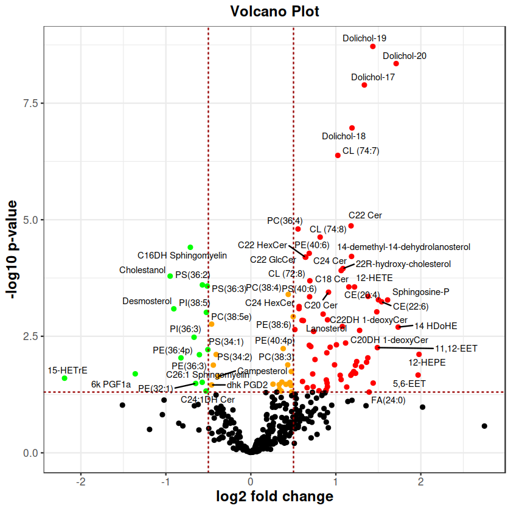

```r
plot_volcano(stats_metabolites, thres_pval= 0.05,thres_log2foldchange = 0.5, TRUE)
```

### Map metabolite class of the significant metabolites utilzing refmet classification in Metabolomics Workbench

This function not only maps metabolite to metabolite class but also to external databases such as pubchem, inchi key, smiles and kegg

In this example, we will go forward with significant metabolite obtained by t-test/

```r
sig_metabolites_kegg_id= map_keggid(sig_metabolites)
#sig_metabolites_kegg_id
save(sig_metabolites_kegg_id, refmet_class, file = "tmp/ST000915_sig_metabolites_kegg_id.RData");
```

#### Check all your significant metabolites have not been assigned metabolite class

```r
setdiff(sig_metabolites$refmet_name, sig_metabolites_kegg_id$refmet_name)
```

### Count metabolites in each of the metabolite class and plotting

You may choose from sub_class, main_class and super_class

```r
count_changes = metcountplot(df_metclass=sig_metabolites_kegg_id, metclass='sub_class', plotting=TRUE, thres_logfC = 0.0, updown_fillcolor=c("red", "green"))
print(count_changes$sig_met_count)
```

```
            sub_class No.of_metabolites                 color
1          1-deoxyCer                 5 increased metabolites
2                 BMP                 2 increased metabolites
3                 Cer                 6 increased metabolites
4        Chol. esters                 5 increased metabolites
5        Cholesterols                 1 increased metabolites
6                  CL                 3 increased metabolites
7                 DAG                 9 increased metabolites
8         Docosanoids                 3 increased metabolites
9           Dolichols                 4 increased metabolites
10             EpETrE                 4 increased metabolites
11               HEPE                 1 increased metabolites
12               HETE                 1 increased metabolites
13             HexCer                 5 increased metabolites
14                LPC                 1 increased metabolites
```

[output cut: 23 more lines]

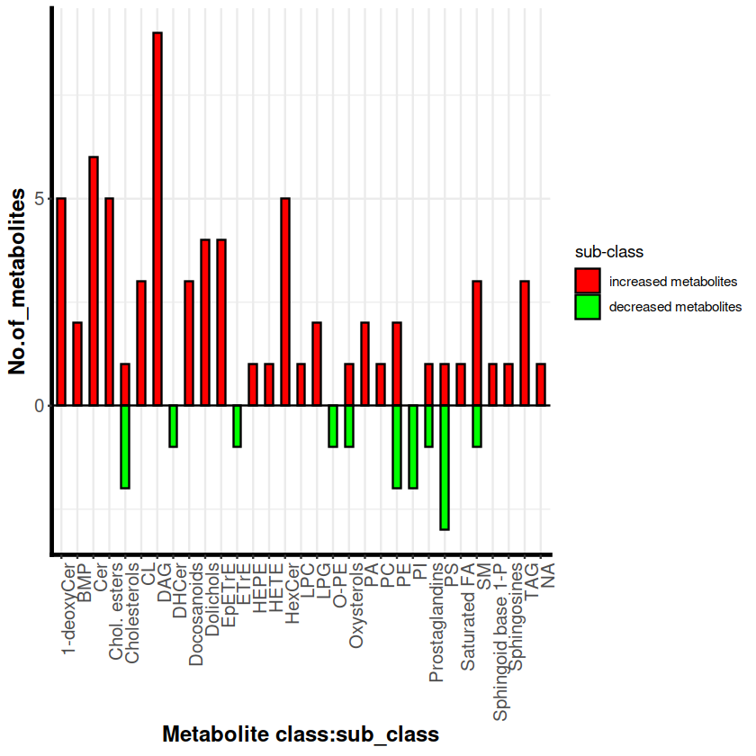

```r
count_changes$plotimg
```

### Enrichment class score

Calculate the enrichment score of each metabolite class. Enrichment score is calculated through hypergeometric method. One can specify the no. of significant metabolites in a class while calculating the enrichment score. We advice to use the number of mtabolites in each class as 3 or more. But if someone just wants to know the enrichment score and rest of the information of all the metabolites, then they can choose the number as 1.

```r
# pass debug = 0 below or comment some lines to suppress some print output
metenrichment = metclassenrichment(df_metclass=sig_metabolites_kegg_id,refmet_class, metclass="sub_class",enrich_stats="HG",no=1, debug = 1)
print(head(metenrichment))
#knitr::kable(head(metenrichment))
metenrichment[metenrichment$main_class %in% c("Ceramides", "Sphingomyelins"), c("Metabolite", "pval", "super_class", "main_class", "sub_class", "HG p-value")]
colnames(metenrichment)
metenrichment$super_class
metenrichment$main_class
metenrichment$sub_class
```

```
[1] "Name = 1-DeoxyCer 18:0;O2/16:0"
[1] "M = 5"                  "L = 84"                 "N = 542"
[4] "k = 24"                 "pp = 0.309198704801185"
[1] "Name = 1-DeoxyCer 18:0;O2/18:0"
[1] "M = 5"                  "L = 84"                 "N = 542"
[4] "k = 24"                 "pp = 0.309198704801185"
[1] "Name = 1-DeoxyCer 18:0;O2/20:0"
[1] "M = 5"                  "L = 84"                 "N = 542"
[4] "k = 24"                 "pp = 0.309198704801185"
[1] "Name = 1-DeoxyCer 18:0;O2/22:0"
[1] "M = 5"                  "L = 84"                 "N = 542"
[4] "k = 24"                 "pp = 0.309198704801185"
[1] "Name = 1-DeoxyCer 18:0;O2/24:0"
[1] "M = 5"                  "L = 84"                 "N = 542"
[4] "k = 24"                 "pp = 0.309198704801185"
```

[output cut: 266 more lines]

A data.frame: 16 × 6

|  | Metabolite <chr> | pval <dbl> | super_class <chr> | main_class <chr> | sub_class <chr> | HG p-value <dbl> |
| --- | --- | --- | --- | --- | --- | --- |
| 1 | C16DH 1-deoxyCer | 4.411384e-03 | Sphingolipids | Ceramides | 1-deoxyCer | 0.3091987 |
| 2 | C18DH 1-deoxyCer | 5.219699e-04 | Sphingolipids | Ceramides | 1-deoxyCer | 0.3091987 |
| 3 | C20DH 1-deoxyCer | 2.366336e-03 | Sphingolipids | Ceramides | 1-deoxyCer | 0.3091987 |
| 4 | C22DH 1-deoxyCer | 9.458421e-04 | Sphingolipids | Ceramides | 1-deoxyCer | 0.3091987 |
| 5 | C24DH 1-deoxyCer | 9.180014e-03 | Sphingolipids | Ceramides | 1-deoxyCer | 0.3091987 |
| 35 | C24:1DH Cer | 4.727138e-02 | Sphingolipids | Ceramides | DHCer | 0.9542318 |
| 36 | C18 Cer | 2.759931e-04 | Sphingolipids | Ceramides | Cer | 0.0452727 |
| 37 | C18:1 Cer | 5.261088e-03 | Sphingolipids | Ceramides | Cer | 0.0452727 |
| 38 | C20 Cer | 3.586497e-04 | Sphingolipids | Ceramides | Cer | 0.0452727 |
| 39 | C22 Cer | 1.351778e-05 | Sphingolipids | Ceramides | Cer | 0.0452727 |
| 40 | C24 Cer | 1.231257e-04 | Sphingolipids | Ceramides | Cer | 0.0452727 |
| 41 | C26 Cer | 4.782389e-02 | Sphingolipids | Ceramides | Cer | 0.0452727 |
| 76 | C16DH Sphingomyelin | 3.904911e-05 | Sphingolipids | Sphingomyelins | SM | 0.5603003 |
| 77 | C18:1 Sphingomyelin | 3.185880e-02 | Sphingolipids | Sphingomyelins | SM | 0.5603003 |
| 78 | C20 Sphingomyelin | 1.441053e-03 | Sphingolipids | Sphingomyelins | SM | 0.5603003 |
| 79 | C22 Sphingomyelin | 1.458968e-03 | Sphingolipids | Sphingomyelins | SM | 0.5603003 |

1. 'refmet_name'

2. 'Exact mass'

3. 'KEGG ID'

4. 'Metabolite'

5. 'Cirrhosis_mean'

6. 'Normal_mean'

7. 'Fold_change'

8. 'log2Fold_change'

9. 't_value'

10. 'pval'

11. 'padj'

12. 'metabolite_id'

13. 'super_class'

14. 'main_class'

15. 'sub_class'

16. 'formula'

17. 'HG p-value'

1. 'Sphingolipids'

2. 'Sphingolipids'

3. 'Sphingolipids'

4. 'Sphingolipids'

5. 'Sphingolipids'

6. 'Glycerolipids'

7. 'Glycerolipids'

8. 'Glycerolipids'

9. 'Glycerolipids'

10. 'Glycerolipids'

11. 'Glycerolipids'

12. 'Glycerolipids'

13. 'Glycerolipids'

14. 'Glycerolipids'

15. 'Fatty Acyls'

16. 'Fatty Acyls'

17. 'Fatty Acyls'

18. 'Fatty Acyls'

19. 'Fatty Acyls'

20. 'Fatty Acyls'

21. 'Fatty Acyls'

22. 'Sterol Lipids'

23. 'Sterol Lipids'

24. 'Fatty Acyls'

25. 'Fatty Acyls'

26. 'Fatty Acyls'

27. 'Fatty Acyls'

28. 'Glycerophospholipids'

29. 'Glycerophospholipids'

30. 'Sterol Lipids'

31. 'Sterol Lipids'

32. 'Sterol Lipids'

33. 'Sterol Lipids'

34. 'Sterol Lipids'

35. 'Sphingolipids'

36. 'Sphingolipids'

37. 'Sphingolipids'

38. 'Sphingolipids'

39. 'Sphingolipids'

40. 'Sphingolipids'

41. 'Sphingolipids'

42. 'Glycerophospholipids'

43. 'Glycerophospholipids'

44. 'Glycerophospholipids'

45. 'Sterol Lipids'

46. 'Sterol Lipids'

47. 'Prenol Lipids'

48. 'Prenol Lipids'

49. 'Prenol Lipids'

50. 'Prenol Lipids'

51. 'Sphingolipids'

52. 'Sphingolipids'

53. 'Sphingolipids'

54. 'Sphingolipids'

55. 'Sphingolipids'

56. 'Sterol Lipids'

57. 'Fatty Acyls'

58. 'Glycerophospholipids'

59. 'Glycerophospholipids'

60. 'Glycerophospholipids'

61. 'Glycerophospholipids'

62. 'Glycerophospholipids'

63. 'Glycerophospholipids'

64. 'Glycerophospholipids'

65. 'Glycerophospholipids'

66. 'Glycerophospholipids'

67. 'Glycerophospholipids'

68. 'Glycerophospholipids'

69. 'Fatty Acyls'

70. 'Glycerophospholipids'

71. 'Glycerophospholipids'

72. 'Glycerophospholipids'

73. 'Glycerophospholipids'

74. 'Glycerophospholipids'

75. 'Glycerophospholipids'

76. 'Sphingolipids'

77. 'Sphingolipids'

78. 'Sphingolipids'

79. 'Sphingolipids'

80. 'Sphingolipids'

81. 'Sphingolipids'

82. 'Glycerolipids'

83. 'Glycerolipids'

84. 'Glycerolipids'

1. 'Ceramides'

2. 'Ceramides'

3. 'Ceramides'

4. 'Ceramides'

5. 'Ceramides'

6. 'Diradylglycerols'

7. 'Diradylglycerols'

8. 'Diradylglycerols'

9. 'Diradylglycerols'

10. 'Diradylglycerols'

11. 'Diradylglycerols'

12. 'Diradylglycerols'

13. 'Diradylglycerols'

14. 'Diradylglycerols'

15. 'Eicosanoids'

16. 'Eicosanoids'

17. 'Eicosanoids'

18. 'Docosanoids'

19. 'Eicosanoids'

20. 'Eicosanoids'

21. 'Docosanoids'

22. 'Sterols'

23. 'Sterols'

24. 'Docosanoids'

25. 'Eicosanoids'

26. 'Eicosanoids'

27. 'Eicosanoids'

28. 'Glycerophosphoglycerols'

29. 'Glycerophosphoglycerols'

30. 'Sterol esters'

31. 'Sterol esters'

32. 'Sterol esters'

33. 'Sterol esters'

34. 'Sterol esters'

35. 'Ceramides'

36. 'Ceramides'

37. 'Ceramides'

38. 'Ceramides'

39. 'Ceramides'

40. 'Ceramides'

41. 'Ceramides'

42. 'Cardiolipins'

43. 'Cardiolipins'

44. 'Cardiolipins'

45. 'Sterols'

46. 'Sterols'

47. 'Polyprenols'

48. 'Polyprenols'

49. 'Polyprenols'

50. 'Polyprenols'

51. 'Glycosphingolipids'

52. 'Glycosphingolipids'

53. 'Glycosphingolipids'

54. 'Glycosphingolipids'

55. 'Glycosphingolipids'

56. 'Sterols'

57. 'Fatty acids'

58. 'Glycerophosphocholines'

59. 'Glycerophosphoglycerols'

60. 'Glycerophosphoglycerols'

61. 'Glycerophosphates'

62. 'Glycerophosphates'

63. 'Glycerophosphocholines'

64. 'Glycerophosphoethanolamines'

65. 'Glycerophosphoethanolamines'

66. 'Glycerophosphoethanolamines'

67. 'Glycerophosphoethanolamines'

68. 'Glycerophosphoethanolamines'

69. 'Eicosanoids'

70. 'Glycerophosphoinositols'

71. 'Glycerophosphoinositols'

72. 'Glycerophosphoserines'

73. 'Glycerophosphoserines'

74. 'Glycerophosphoserines'

75. 'Glycerophosphoserines'

76. 'Sphingomyelins'

77. 'Sphingomyelins'

78. 'Sphingomyelins'

79. 'Sphingomyelins'

80. 'Sphingoid bases'

81. 'Sphingoid bases'

82. 'Triradylglycerols'

83. 'Triradylglycerols'

84. 'Triradylglycerols'

1. '1-deoxyCer'

2. '1-deoxyCer'

3. '1-deoxyCer'

4. '1-deoxyCer'

5. '1-deoxyCer'

6. 'DAG'

7. 'DAG'

8. 'DAG'

9. 'DAG'

10. 'DAG'

11. 'DAG'

12. 'DAG'

13. 'DAG'

14. 'DAG'

15. 'EpETrE'

16. 'HEPE'

17. 'HETE'

18. 'Docosanoids'

19. 'EpETrE'

20. 'ETrE'

21. 'Docosanoids'

22. 'Oxysterols'

23. 'Oxysterols'

24. 'Docosanoids'

25. 'EpETrE'

26. 'Prostaglandins'

27. 'EpETrE'

28. 'BMP'

29. 'BMP'

30. 'Chol. esters'

31. 'Chol. esters'

32. 'Chol. esters'

33. 'Chol. esters'

34. 'Chol. esters'

35. 'DHCer'

36. 'Cer'

37. 'Cer'

38. 'Cer'

39. 'Cer'

40. 'Cer'

41. 'Cer'

42. 'CL'

43. 'CL'

44. 'CL'

45. 'Cholesterols'

46. 'Cholesterols'

47. 'Dolichols'

48. 'Dolichols'

49. 'Dolichols'

50. 'Dolichols'

51. 'HexCer'

52. 'HexCer'

53. 'HexCer'

54. 'HexCer'

55. 'HexCer'

56. 'Cholesterols'

57. 'Saturated FA'

58. 'LPC'

59. 'LPG'

60. 'LPG'

61. 'PA'

62. 'PA'

63. 'PC'

64. 'PE'

65. 'PE'

66. 'PE'

67. 'PE'

68. 'O-PE'

69. 'Prostaglandins'

70. 'PI'

71. 'PI'

72. 'PS'

73. 'PS'

74. 'PS'

75. 'PS'

76. 'SM'

77. 'SM'

78. 'SM'

79. 'SM'

80. 'Sphingosines'

81. 'Sphingoid base 1-P'

82. 'TAG'

83. 'TAG'

84. 'TAG'

#### Plot the enrichment score via function plot_met_enrichment

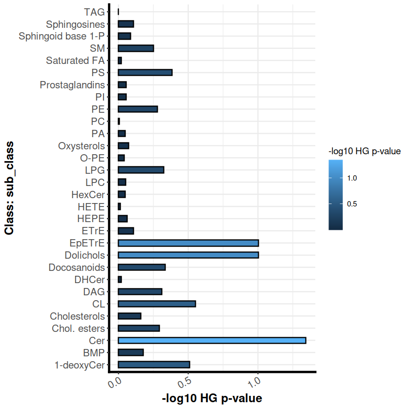

```r
plot_met_enrichment(metenrichment, "sub_class","HG", no=1)
#plot_met_enrichment(metenrichment, "main_class","HG", no=1)
#plot_met_enrichment(metenrichment, "super_class","HG", no=1)
```

### Check the pathways with reactions of all the significant metabolites

```r
met_path = met_pathways(df_metenrichment = metenrichment, 'hsa')
head(met_path)
```

A data.frame: 6 × 22

|  | rxn <chr> | refmet_name <chr> | Exact mass <chr> | KEGG ID <chr> | Metabolite <chr> | Cirrhosis_mean <chr> | Normal_mean <chr> | Fold_change <dbl> | log2Fold_change <dbl> | t_value <dbl> | ⋯ | metabolite_id <named list> | super_class <chr> | main_class <chr> | sub_class <chr> | formula <chr> | HG p-value <dbl> | Rxn_name <named list> | PATHWAY <chr> | pathway_id <chr> | sps_path_id <chr> |
| --- | --- | --- | --- | --- | --- | --- | --- | --- | --- | --- | --- | --- | --- | --- | --- | --- | --- | --- | --- | --- | --- |
| 1 | R01003 | Dolichol-20 | 1381.2782 | C00381 | Dolichol-20 | 18.54100 | 60.64903 | 3.271077 | 1.7097655 | -7.141005 | ⋯ | ME231044 | Prenol Lipids | Polyprenols | Dolichols | C100H164O | 0.0991928 | dolichyl-phosphate phosphohydrolase | N-Glycan biosynthesis | rn00510 | hsa00510 |
| 2 | R01003 | Dolichol-20 | 1381.2782 | C00381 | Dolichol-20 | 18.54100 | 60.64903 | 3.271077 | 1.7097655 | -7.141005 | ⋯ | ME231044 | Prenol Lipids | Polyprenols | Dolichols | C100H164O | 0.0991928 | dolichyl-phosphate phosphohydrolase | Metabolic pathways | rn01100 | hsa01100 |
| 3 | R01018 | Dolichol-20 | 1381.2782 | C00381 | Dolichol-20 | 18.54100 | 60.64903 | 3.271077 | 1.7097655 | -7.141005 | ⋯ | ME231044 | Prenol Lipids | Polyprenols | Dolichols | C100H164O | 0.0991928 | CTP:dolichol O-phosphotransferase | N-Glycan biosynthesis | rn00510 | hsa00510 |
| 4 | R01018 | Dolichol-20 | 1381.2782 | C00381 | Dolichol-20 | 18.54100 | 60.64903 | 3.271077 | 1.7097655 | -7.141005 | ⋯ | ME231044 | Prenol Lipids | Polyprenols | Dolichols | C100H164O | 0.0991928 | CTP:dolichol O-phosphotransferase | Metabolic pathways | rn01100 | hsa01100 |
| 5 | R01310 | PC 36:4 | 781.5622 | C00157 | PC(36:4) | 1025.012 | 1505.988 | 1.469239 | 0.5550695 | -4.795876 | ⋯ | ME231358 | Glycerophospholipids | Glycerophosphocholines | PC | C44H80NO8P | 0.9866322 | phosphatidylcholine phosphatidohydrolase | Glycerophospholipid metabolism | rn00564 | hsa00564 |
| 6 | R01310 | PC 36:4 | 781.5622 | C00157 | PC(36:4) | 1025.012 | 1505.988 | 1.469239 | 0.5550695 | -4.795876 | ⋯ | ME231358 | Glycerophospholipids | Glycerophosphocholines | PC | C44H80NO8P | 0.9866322 | phosphatidylcholine phosphatidohydrolase | Metabolic pathways | rn01100 | hsa01100 |

Find metabolites for which no pathways were registered in Kegg and/or no kegg id was found

```r
setdiff(metenrichment$Metabolite,unique(met_path$Metabolite))
```

1. 'C16DH 1-deoxyCer'

2. 'C18DH 1-deoxyCer'

3. 'C20DH 1-deoxyCer'

4. 'C22DH 1-deoxyCer'

5. 'C24DH 1-deoxyCer'

6. '12-HEPE'

7. '12-HETE'

8. '14 HDoHE'

9. '15-HETrE'

10. '16 HDoHE'

11. '4 HDoHE'

12. 'BMP(40:7)'

13. 'BMP(40:8)'

14. 'CE(18:2)'

15. 'CE(18:3)'

16. 'CE(20:3)'

17. 'CE(20:4)'

18. 'CL (72:8)'

19. 'CL (74:7)'

20. 'CL (74:8)'

21. 'Cholestanol'

22. 'Dolichol-17'

23. 'Dolichol-18'

24. 'Dolichol-19'

### Get pathway enrichment sore.

Once we have the pathway information, we can calculate enrichment score of pathways. Again, here i have used hypergeometric score. For hypergeometric score, we need to know the total number of kegg compounds that are linked to kegg pathways. N = total no. of cmpds linked to kegg pathway (this is the step which might take long), so I advice to run the script comp_linkedto_pathways() just the first time or after 6 months or so if desired to run the pipeline again. save the result from comp_linkedto_pathways() and load it. Loading from saved file would save time for another analysis with another study. However the package takes care of loading. Save the data in the data folder.

L = No. of cmpds in a pathway M= no. of altered cmpds in a pathway K = total no. of altered cmpds phyper(M,L, N-L, K)

This function also utilizes korg dataset from pathview package.

```r
load('../data/ls_path.RData')
load('../data/korg.RData')
kegg_es = path_enrichmentscore(met_path,sig_metabolite_kegg_id=sig_metabolite_kegg_id,ls_path=ls_path,refmet_class=refmet_class,sps='hsa',padj='BH', kegg_comp_path=FALSE)
```

```r
head(kegg_es)
```

A data.frame: 6 × 5

|  | Pathway name <fct> | No.of mets in study <int> | Total_no._of_comps_in_pathway <int> | pathway_HG p-value <dbl> | Padjust <dbl> |
| --- | --- | --- | --- | --- | --- |
| 1 | alpha-Linolenic acid metabolism | 4 | 44 | 9.380043e-01 | 1.000000e+00 |
| 2 | Arachidonic acid metabolism | 8 | 75 | 9.330122e-01 | 1.000000e+00 |
| 3 | Biosynthesis of unsaturated fatty acids | 1 | 74 | 9.999988e-01 | 1.000000e+00 |
| 4 | Ether lipid metabolism | 1 | 25 | 9.873619e-01 | 1.000000e+00 |
| 5 | Glycerolipid metabolism | 14 | 38 | 7.720993e-04 | 3.281422e-03 |
| 6 | Glycerophospholipid metabolism | 25 | 56 | 3.418221e-08 | 1.936992e-07 |

### Plot pathway network

The pathway network is such that it shows metabolites that are connected to different pathways and same metabolite in different pathway. Color of nodes of metabolites are according to the fold change of metabolites (low expression in green and high in red) and size of pathway nodes (square nodes) are according to the number of branches (meaning no of metabolites). All metabolite are written in blue

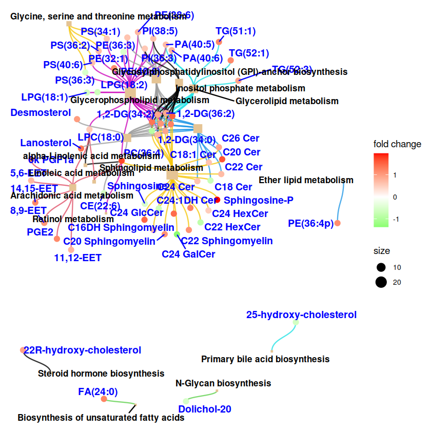

```r
plot_pathway_networks (met_path,kegg_es, TRUE)
```

### Heatmap

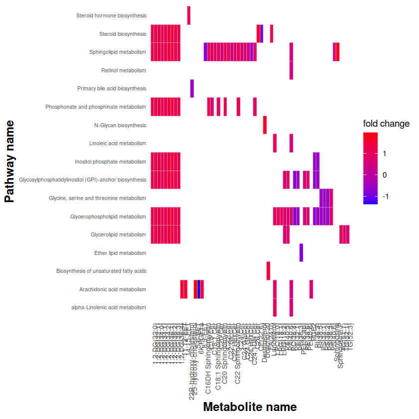

```r
plot_heatmap(met_path, shorten_name=TRUE,refmet_name=FALSE, xaxis=8, yaxis=6)
```

### Dotplot

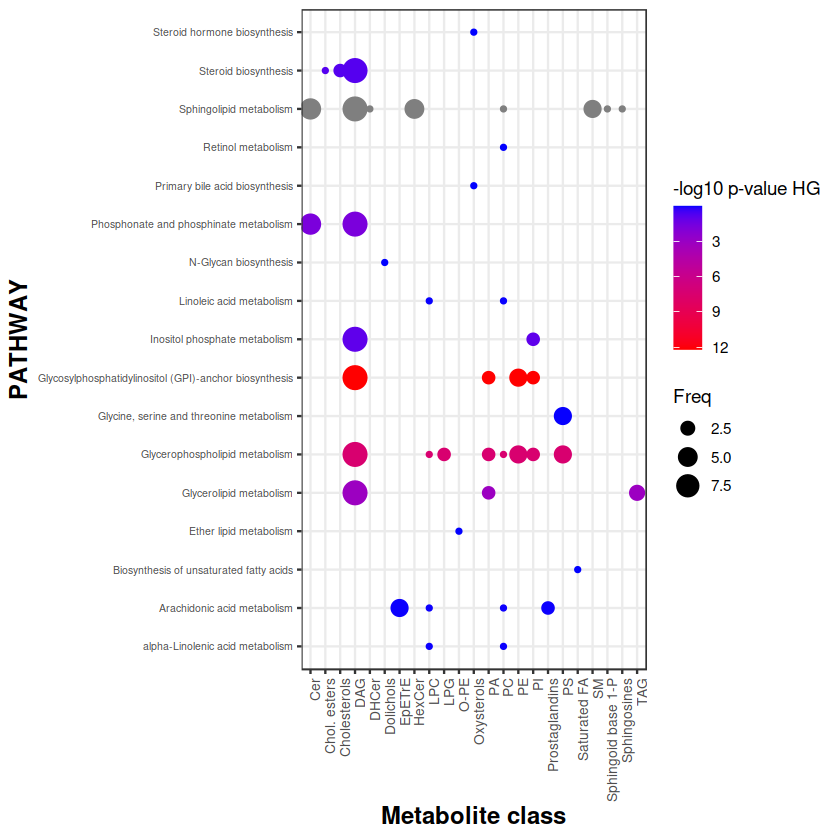

```r
dotplot_met_class_path (met_path, kegg_es,"sub_class",xaxis=8,yaxis=6)
```

### Get the gene and enzyme info

Here we get the information of genes involved in enriched pathways for specified organism

```r
met_gene_info = enzyme_gene_info (metenrichment, "hsa","sub_class")
head(met_gene_info)
```

A data.frame: 6 × 17

|  | orthology_id <chr> | ORTHOLOGY <chr> | gene_id <named list> | gene_name <named list> | ORGANISM <named list> | PATHWAY <named list> | DBLINKS <named list> | MOTIF <named list> | rxn <chr> | Metabolite <chr> | KEGG ID <chr> | sub_class <chr> | Rxn_name <named list> | RCLASS <named list> | EQUATION <named list> | EQUATION_more <named list> | ENZYME <named list> |
| --- | --- | --- | --- | --- | --- | --- | --- | --- | --- | --- | --- | --- | --- | --- | --- | --- | --- |
| 1 | K00079 | carbonyl reductase 1 [EC:1.1.1.184 1.1.1.189 1.1.1.197] | 873 | (RefSeq) carbonyl reductase 1 | Homo sapiens (human) | Arachidonic acid metabolism , Folate biosynthesis , Metabolism of xenobiotics by cytochrome P450 , Metabolic pathways , Chemical carcinogenesis - DNA adducts , Chemical carcinogenesis - reactive oxyge… | NCBI-GeneID: 873 , NCBI-ProteinID: NP_001748 , OMIM: 114830 , HGNC: 1548 , Ensembl: ENSG00000159228 , Pharos: P16152(Tchem) , UniProt: P16152 A0A384NL53 | Pfam: adh_short adh_short_C2 KR Epimerase | R02581 | PGE2 | C00584 | Prostaglandins | (5Z,13E)-(15S)-9alpha,11alpha,15-trihydroxyprosta-5,13-dienoate:NADP+ 9-oxidoreductase;, Prostaglandin F2alpha:NADP+ oxidoreductase | RC00001 C00005_C00006, RC00154 C00584_C00639 | C00639 + C00006 <=> C00584 + C00005 + C00080 | Prostaglandin F2alpha + NADP+ <=> Prostaglandin E2 + NADPH + H+ | 1.1.1.184, 1.1.1.189 |
| 2 | K00084 | carbonyl reductase 3 [EC:1.1.1.184] | 874 | (RefSeq) carbonyl reductase 3 | Homo sapiens (human) | Arachidonic acid metabolism , Metabolism of xenobiotics by cytochrome P450, Metabolic pathways | NCBI-GeneID: 874 , NCBI-ProteinID: NP_001227, OMIM: 603608 , HGNC: 1549 , Ensembl: ENSG00000159231 , Pharos: O75828(Tbio) , UniProt: O75828 V9HW40 | Pfam: adh_short adh_short_C2 KR Epimerase DUF6513 Sacchrp_dh_NADP | R02581 | PGE2 | C00584 | Prostaglandins | (5Z,13E)-(15S)-9alpha,11alpha,15-trihydroxyprosta-5,13-dienoate:NADP+ 9-oxidoreductase;, Prostaglandin F2alpha:NADP+ oxidoreductase | RC00001 C00005_C00006, RC00154 C00584_C00639 | C00639 + C00006 <=> C00584 + C00005 + C00080 | Prostaglandin F2alpha + NADP+ <=> Prostaglandin E2 + NADPH + H+ | 1.1.1.184, 1.1.1.189 |
| 3 | K00498 | cholesterol monooxygenase (side-chain-cleaving) [EC:1.14.15.6] | 1583 | (RefSeq) cytochrome P450 family 11 subfamily A member 1 | Homo sapiens (human) | Steroid hormone biosynthesis , Metabolic pathways , Ovarian steroidogenesis , Aldosterone synthesis and secretion, Cortisol synthesis and secretion , Cushing syndrome | NCBI-GeneID: 1583 , NCBI-ProteinID: NP_000772 , OMIM: 118485 , HGNC: 2590 , Ensembl: ENSG00000140459 , Pharos: P05108(Tclin) , UniProt: P05108 A0A0S2Z3R3 | Pfam: p450 | R02723 | 22R-hydroxy-cholesterol | C05502 | Oxysterols | NULL | RC00773 C00187_C05502 | C00187 + C00007 + 2 C00662 + 2 C00080 <=> C05502 + C00001 + 2 C00667 | Cholesterol + Oxygen + 2 Reduced adrenal ferredoxin + 2 H+ <=> 22(R)-Hydroxycholesterol + H2O + 2 Oxidized adrenal ferredoxin | 1.14.15.6 |
| 4 | K00498 | cholesterol monooxygenase (side-chain-cleaving) [EC:1.14.15.6] | 1583 | (RefSeq) cytochrome P450 family 11 subfamily A member 1 | Homo sapiens (human) | Steroid hormone biosynthesis , Metabolic pathways , Ovarian steroidogenesis , Aldosterone synthesis and secretion, Cortisol synthesis and secretion , Cushing syndrome | NCBI-GeneID: 1583 , NCBI-ProteinID: NP_000772 , OMIM: 118485 , HGNC: 2590 , Ensembl: ENSG00000140459 , Pharos: P05108(Tclin) , UniProt: P05108 A0A0S2Z3R3 | Pfam: p450 | R04855 | 22R-hydroxy-cholesterol | C05502 | Oxysterols | 22beta-Hydroxycholesterol:oxygen oxidoreductase (side-chain-cleaving) | RC00706 C05501_C05502 | C05502 + C00007 + 2 C00662 + 2 C00080 <=> C05501 + C00001 + 2 C00667 | 22(R)-Hydroxycholesterol + Oxygen + 2 Reduced adrenal ferredoxin + 2 H+ <=> 20alpha,22beta-Dihydroxycholesterol + H2O + 2 Oxidized adrenal ferredoxin | 1.14.15.6 |
| 5 | K00551 | phosphatidylethanolamine/phosphatidyl-N-methylethanolamine N-methyltransferase [EC:2.1.1.17 2.1.1.71] | 10400 | (RefSeq) phosphatidylethanolamine N-methyltransferase | Homo sapiens (human) | Glycerophospholipid metabolism, Metabolic pathways | NCBI-GeneID: 10400 , NCBI-ProteinID: NP_009100, OMIM: 602391 , HGNC: 8830 , Ensembl: ENSG00000133027 , Pharos: Q9UBM1(Tbio) , UniProt: Q9UBM1 | Pfam: PEMT Herpes_UL74 EptA_B_N | R02056 | PE(40:6) | C00350 | PE | S-adenosyl-L-methionine:phosphatidylethanolamine N-methyltransferase | RC00003 C00019_C00021, RC00060 C00350_C01241 | C00019 + C00350 <=> C00021 + C01241 | S-Adenosyl-L-methionine + Phosphatidylethanolamine <=> S-Adenosyl-L-homocysteine + Phosphatidyl-N-methylethanolamine | 2.1.1.17 |
| 6 | K00551 | phosphatidylethanolamine/phosphatidyl-N-methylethanolamine N-methyltransferase [EC:2.1.1.17 2.1.1.71] | 10400 | (RefSeq) phosphatidylethanolamine N-methyltransferase | Homo sapiens (human) | Glycerophospholipid metabolism, Metabolic pathways | NCBI-GeneID: 10400 , NCBI-ProteinID: NP_009100, OMIM: 602391 , HGNC: 8830 , Ensembl: ENSG00000133027 , Pharos: Q9UBM1(Tbio) , UniProt: Q9UBM1 | Pfam: PEMT Herpes_UL74 EptA_B_N | R02056 | PE(36:3) | C00350 | PE | S-adenosyl-L-methionine:phosphatidylethanolamine N-methyltransferase | RC00003 C00019_C00021, RC00060 C00350_C01241 | C00019 + C00350 <=> C00021 + C01241 | S-Adenosyl-L-methionine + Phosphatidylethanolamine <=> S-Adenosyl-L-homocysteine + Phosphatidyl-N-methylethanolamine | 2.1.1.17 |

#### Get the information if metabolite is a reactant or substrate

```r
rclass_info = react_substrate(met_gene_info)
head(rclass_info)
```

A data.frame: 6 × 18

|  | orthology_id <chr> | ORTHOLOGY <chr> | gene_id <named list> | gene_name <named list> | ORGANISM <named list> | PATHWAY <named list> | DBLINKS <named list> | MOTIF <named list> | rxn <chr> | Metabolite <chr> | KEGG ID <chr> | sub_class <chr> | Rxn_name <named list> | RCLASS <named list> | EQUATION <named list> | EQUATION_more <named list> | ENZYME <named list> | reactant_product <chr> |
| --- | --- | --- | --- | --- | --- | --- | --- | --- | --- | --- | --- | --- | --- | --- | --- | --- | --- | --- |
| 1 | K00079 | carbonyl reductase 1 [EC:1.1.1.184 1.1.1.189 1.1.1.197] | 873 | (RefSeq) carbonyl reductase 1 | Homo sapiens (human) | Arachidonic acid metabolism , Folate biosynthesis , Metabolism of xenobiotics by cytochrome P450 , Metabolic pathways , Chemical carcinogenesis - DNA adducts , Chemical carcinogenesis - reactive oxyge… | NCBI-GeneID: 873 , NCBI-ProteinID: NP_001748 , OMIM: 114830 , HGNC: 1548 , Ensembl: ENSG00000159228 , Pharos: P16152(Tchem) , UniProt: P16152 A0A384NL53 | Pfam: adh_short adh_short_C2 KR Epimerase | R02581 | PGE2 | C00584 | Prostaglandins | (5Z,13E)-(15S)-9alpha,11alpha,15-trihydroxyprosta-5,13-dienoate:NADP+ 9-oxidoreductase;, Prostaglandin F2alpha:NADP+ oxidoreductase | RC00001 C00005_C00006, RC00154 C00584_C00639 | C00639 + C00006 <=> C00584 + C00005 + C00080 | Prostaglandin F2alpha + NADP+ <=> Prostaglandin E2 + NADPH + H+ | 1.1.1.184, 1.1.1.189 | Product |
| 2 | K00084 | carbonyl reductase 3 [EC:1.1.1.184] | 874 | (RefSeq) carbonyl reductase 3 | Homo sapiens (human) | Arachidonic acid metabolism , Metabolism of xenobiotics by cytochrome P450, Metabolic pathways | NCBI-GeneID: 874 , NCBI-ProteinID: NP_001227, OMIM: 603608 , HGNC: 1549 , Ensembl: ENSG00000159231 , Pharos: O75828(Tbio) , UniProt: O75828 V9HW40 | Pfam: adh_short adh_short_C2 KR Epimerase DUF6513 Sacchrp_dh_NADP | R02581 | PGE2 | C00584 | Prostaglandins | (5Z,13E)-(15S)-9alpha,11alpha,15-trihydroxyprosta-5,13-dienoate:NADP+ 9-oxidoreductase;, Prostaglandin F2alpha:NADP+ oxidoreductase | RC00001 C00005_C00006, RC00154 C00584_C00639 | C00639 + C00006 <=> C00584 + C00005 + C00080 | Prostaglandin F2alpha + NADP+ <=> Prostaglandin E2 + NADPH + H+ | 1.1.1.184, 1.1.1.189 | Product |
| 3 | K00498 | cholesterol monooxygenase (side-chain-cleaving) [EC:1.14.15.6] | 1583 | (RefSeq) cytochrome P450 family 11 subfamily A member 1 | Homo sapiens (human) | Steroid hormone biosynthesis , Metabolic pathways , Ovarian steroidogenesis , Aldosterone synthesis and secretion, Cortisol synthesis and secretion , Cushing syndrome | NCBI-GeneID: 1583 , NCBI-ProteinID: NP_000772 , OMIM: 118485 , HGNC: 2590 , Ensembl: ENSG00000140459 , Pharos: P05108(Tclin) , UniProt: P05108 A0A0S2Z3R3 | Pfam: p450 | R02723 | 22R-hydroxy-cholesterol | C05502 | Oxysterols | NULL | RC00773 C00187_C05502 | C00187 + C00007 + 2 C00662 + 2 C00080 <=> C05502 + C00001 + 2 C00667 | Cholesterol + Oxygen + 2 Reduced adrenal ferredoxin + 2 H+ <=> 22(R)-Hydroxycholesterol + H2O + 2 Oxidized adrenal ferredoxin | 1.14.15.6 | Product |
| 4 | K00498 | cholesterol monooxygenase (side-chain-cleaving) [EC:1.14.15.6] | 1583 | (RefSeq) cytochrome P450 family 11 subfamily A member 1 | Homo sapiens (human) | Steroid hormone biosynthesis , Metabolic pathways , Ovarian steroidogenesis , Aldosterone synthesis and secretion, Cortisol synthesis and secretion , Cushing syndrome | NCBI-GeneID: 1583 , NCBI-ProteinID: NP_000772 , OMIM: 118485 , HGNC: 2590 , Ensembl: ENSG00000140459 , Pharos: P05108(Tclin) , UniProt: P05108 A0A0S2Z3R3 | Pfam: p450 | R04855 | 22R-hydroxy-cholesterol | C05502 | Oxysterols | 22beta-Hydroxycholesterol:oxygen oxidoreductase (side-chain-cleaving) | RC00706 C05501_C05502 | C05502 + C00007 + 2 C00662 + 2 C00080 <=> C05501 + C00001 + 2 C00667 | 22(R)-Hydroxycholesterol + Oxygen + 2 Reduced adrenal ferredoxin + 2 H+ <=> 20alpha,22beta-Dihydroxycholesterol + H2O + 2 Oxidized adrenal ferredoxin | 1.14.15.6 | Substrate |
| 5 | K00551 | phosphatidylethanolamine/phosphatidyl-N-methylethanolamine N-methyltransferase [EC:2.1.1.17 2.1.1.71] | 10400 | (RefSeq) phosphatidylethanolamine N-methyltransferase | Homo sapiens (human) | Glycerophospholipid metabolism, Metabolic pathways | NCBI-GeneID: 10400 , NCBI-ProteinID: NP_009100, OMIM: 602391 , HGNC: 8830 , Ensembl: ENSG00000133027 , Pharos: Q9UBM1(Tbio) , UniProt: Q9UBM1 | Pfam: PEMT Herpes_UL74 EptA_B_N | R02056 | PE(40:6) | C00350 | PE | S-adenosyl-L-methionine:phosphatidylethanolamine N-methyltransferase | RC00003 C00019_C00021, RC00060 C00350_C01241 | C00019 + C00350 <=> C00021 + C01241 | S-Adenosyl-L-methionine + Phosphatidylethanolamine <=> S-Adenosyl-L-homocysteine + Phosphatidyl-N-methylethanolamine | 2.1.1.17 | Substrate |
| 6 | K00551 | phosphatidylethanolamine/phosphatidyl-N-methylethanolamine N-methyltransferase [EC:2.1.1.17 2.1.1.71] | 10400 | (RefSeq) phosphatidylethanolamine N-methyltransferase | Homo sapiens (human) | Glycerophospholipid metabolism, Metabolic pathways | NCBI-GeneID: 10400 , NCBI-ProteinID: NP_009100, OMIM: 602391 , HGNC: 8830 , Ensembl: ENSG00000133027 , Pharos: Q9UBM1(Tbio) , UniProt: Q9UBM1 | Pfam: PEMT Herpes_UL74 EptA_B_N | R02056 | PE(36:3) | C00350 | PE | S-adenosyl-L-methionine:phosphatidylethanolamine N-methyltransferase | RC00003 C00019_C00021, RC00060 C00350_C01241 | C00019 + C00350 <=> C00021 + C01241 | S-Adenosyl-L-methionine + Phosphatidylethanolamine <=> S-Adenosyl-L-homocysteine + Phosphatidyl-N-methylethanolamine | 2.1.1.17 | Substrate |

#### Get gene info in short form

```r
met_gene_info2=data.table::data.table(rclass_info)[,lapply(.SD, function(x) toString(unique(x))), by = 'Metabolite']
```